# Project2_B : Color vs Heating/Cooling Dataset

Vishal Arora

Samriti Malhotra

March 10, 2019

# Introduction :-

The excerise is part of taking up various messy data sets and using tidyr and dplyr packages to transform them and infer based on the analysis done. Data preperation/manipulation is the process where data is rearranged, manipulated and prepared for the Analysis to be fed into Model

## Problem Statement :-

We have a dataset which has five colors cloths and how they react to colling and heating after every 10 minutes , now this dataset looks pretty simple but it little messyand needs transofmration before we can analyse it and infer something meaning full from it.

## Solution :-

The R packages used for the solution are as below.  
*dplyr*  
*tidyr*  
*ggplot2*  
*kableExtra*

1. We load the data using read.csv file and display the raw data using kableExtra library methods in a table using the twitter css styling.
2. Using filter method from dplyr library we seregate the raw_data data frame into 2 new data frames based on the phase condition of (“cooling”, “heating”).
3. Now using the ggplot, geom_point, geom_line & scale_x_discrete methods from ggplot2 library we plot the color on x-axis and temperature on y-axis and plot showing the effect of cooling and heating on various color (cloth).

```r
raw_data <- read.csv("science proj data .csv")

df_cooling <- dplyr::filter(raw_data, raw_data$phase == "cooling")

kable(head(df_cooling,n=3)) %>%
  kable_styling(bootstrap_options = c("striped","hover","condensed","responsive"),full_width   = F,position = "left",font_size = 12) %>%
  row_spec(0, background ="darkgray")
```

| color | minute.0 | minute.10 | minute.20 | minute.30 | minute.40 | minute.50 | minute.60 | phase |
| --- | --- | --- | --- | --- | --- | --- | --- | --- |
| white | 98 | 96 | 93 | 80 | 78 | 78 | 78 | cooling |
| red | 109 | 106 | 95 | 87 | 82 | 80 | 78 | cooling |
| pink | 102 | 96 | 90 | 83 | 80 | 78 | 78 | cooling |

```r
df_heating <- dplyr::filter(raw_data, raw_data$phase == 'heating')
kable(head(df_heating,n=3)) %>%
  kable_styling(bootstrap_options = c("striped","hover","condensed","responsive"),full_width   = F,position = "left",font_size = 12) %>%
  row_spec(0, background ="lightgray")
```

| color | minute.0 | minute.10 | minute.20 | minute.30 | minute.40 | minute.50 | minute.60 | phase |
| --- | --- | --- | --- | --- | --- | --- | --- | --- |
| white | 78 | 81 | 83 | 88 | 93 | 96 | 98 | heating |
| red | 78 | 82 | 90 | 93 | 98 | 106 | 109 | heating |
| pink | 78 | 82 | 84 | 90 | 96 | 99 | 102 | heating |

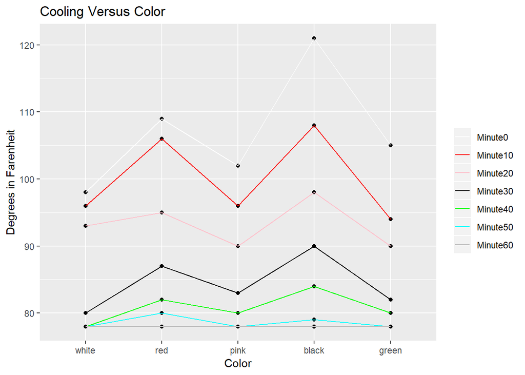

```r
df_cooling %>% ggplot(aes(x=df_cooling$color)) + scale_x_discrete(limits=df_cooling$color) +
  geom_point(aes(y=df_cooling$minute.0 , group=1)) + geom_line(aes(y=df_cooling$minute.0, group=1, col="Minute0")) +
  geom_point(aes(y=df_cooling$minute.10, group=1)) + geom_line(aes(y=df_cooling$minute.10, group=1, col="Minute10")) +
    geom_point(aes(y=df_cooling$minute.20 , group=1)) + geom_line(aes(y=df_cooling$minute.20, group=1, col="Minute20")) +
  geom_point(aes(y=df_cooling$minute.30, group=1)) + geom_line(aes(y=df_cooling$minute.30, group=1, col="Minute30")) +
  geom_point(aes(y=df_cooling$minute.40, group=1)) + geom_line(aes(y=df_cooling$minute.40, group=1, col="Minute40")) +
  geom_point(aes(y=df_cooling$minute.50, group=1)) + geom_line(aes(y=df_cooling$minute.50, group=1, col="Minute50")) +
  geom_point(aes(y=df_cooling$minute.60, group=1)) + geom_line(aes(y=df_cooling$minute.60, group=1, col="Minute60")) +
  labs(title="Cooling Versus Color", x="Color", y="Degrees in Farenheit", colour="") +
  scale_colour_manual(values = c("white", "red" , "pink" , "black", "green" , "cyan" , "grey"))
```

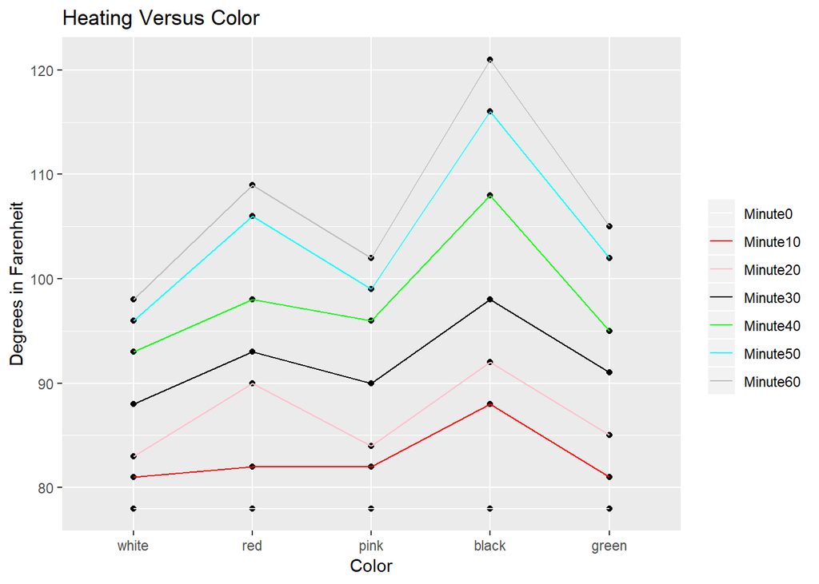

```r
df_heating %>% ggplot(aes(x=df_heating$color)) + scale_x_discrete(limits=df_heating$color) +
  geom_point(aes(y=df_heating$minute.0 , group=1)) + geom_line(aes(y=df_heating$minute.0, group=1, col="Minute0")) +
  geom_point(aes(y=df_heating$minute.10, group=1)) + geom_line(aes(y=df_heating$minute.10, group=1, col="Minute10")) +
    geom_point(aes(y=df_heating$minute.20 , group=1)) + geom_line(aes(y=df_heating$minute.20, group=1, col="Minute20")) +
  geom_point(aes(y=df_heating$minute.30, group=1)) + geom_line(aes(y=df_heating$minute.30, group=1, col="Minute30")) +
  geom_point(aes(y=df_heating$minute.40, group=1)) + geom_line(aes(y=df_heating$minute.40, group=1, col="Minute40")) +
  geom_point(aes(y=df_heating$minute.50, group=1)) + geom_line(aes(y=df_heating$minute.50, group=1, col="Minute50")) +
  geom_point(aes(y=df_heating$minute.60, group=1)) + geom_line(aes(y=df_heating$minute.60, group=1, col="Minute60")) +
  labs(title="Heating Versus Color", x="Color", y="Degrees in Farenheit", colour="") +
  scale_colour_manual(values = c("white", "red" , "pink" , "black", "green" , "cyan" , "grey"))
```

## Summary :-

Thus we can conclude that When a color (colored fabric) absorbs light, it turns the light into thermal energy (heat). The more light a color absorbs, the more thermal energy it produces. Black fabric absorbs all colors of light and is therefore warmer than white fabric which reflects all colors.The same is clearly depicted from the 2 above graphs.